# Frame Distribution by Party and Brexit Position

This notebook analyzes the frame distribution within the "Conservatives" and "Labour" parties and examines differences between MPs who voted for or against Brexit. The analysis is based on annotated chunks in `thesis_final.duckdb`.

**Focus:**

- Only Conservatives and Labour
- Split by Brexit position (Leave vs. Remain)
- MPs without Brexit position are excluded

```
Database: /Users/julianbeese/Developer/Master/master_thesis_data_analysis/thesis_final.duckdb
```

## Data Query

We load chunks with frame labels, party information, and Brexit positions. The join follows the path `chunks.speech_id → speeches.speech_id` and `speeches.twfy_id → MPS.twfy_id`. We filter for:

- Conservatives and Labour
- Only MPs with known Brexit position (brexit_vote IS NOT NULL)
- Only annotated chunks (frame_label IS NOT NULL)

```
Number of chunks: 39941

Available frame labels: ['conflict', 'economic', 'human impact', 'moral value', 'none', 'powerlessness']

Parties: ['Conservative', 'Labour']

Brexit positions: ['Leave', 'Remain']
```

|  | chunk_id | frame_label | debate_id | debate_date | party | brexit_vote | debate_year |
| --- | --- | --- | --- | --- | --- | --- | --- |
| 0 | chunk_000005 | none | uk.org.publicwhip/debate/2012-01-10b.1.1 | 2012-01-10 | Conservative | Leave | 2012 |
| 1 | chunk_000006 | powerlessness | uk.org.publicwhip/debate/2012-01-10b.1.1 | 2012-01-10 | Conservative | Leave | 2012 |
| 2 | chunk_000008 | powerlessness | uk.org.publicwhip/debate/2012-01-10b.1.1 | 2012-01-10 | Labour | Remain | 2012 |
| 3 | chunk_000011 | conflict | uk.org.publicwhip/debate/2012-01-17b.595.6 | 2012-01-17 | Conservative | Remain | 2012 |
| 4 | chunk_000018 | conflict | uk.org.publicwhip/debate/2012-01-19a.908.1 | 2012-01-19 | Conservative | Leave | 2012 |

## Data Overview

We first check the data coverage: How many chunks do we have per party and Brexit position?

```
Number of chunks per party and Brexit position:
```

|  | party | brexit_vote | chunk_count |
| --- | --- | --- | --- |
| 0 | Conservative | Leave | 12332 |
| 1 | Conservative | Remain | 13533 |
| 2 | Labour | Leave | 401 |
| 3 | Labour | Remain | 13675 |

```
Total per party:
```

|  | party | total_chunks |
| --- | --- | --- |
| 0 | Conservative | 25865 |
| 1 | Labour | 14076 |

```
Total per Brexit position:
```

|  | brexit_vote | total_chunks |
| --- | --- | --- |
| 0 | Leave | 12733 |
| 1 | Remain | 27208 |

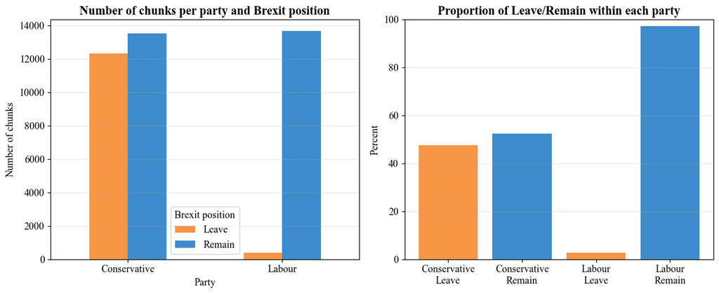

```
Frame distribution (count and proportion):
```

|  | party | brexit_vote | frame_label | count | share |
| --- | --- | --- | --- | --- | --- |
| 5 | Conservative | Leave | powerlessness | 3451 | 0.279841 |
| 4 | Conservative | Leave | none | 2614 | 0.211969 |
| 1 | Conservative | Leave | economic | 2513 | 0.203779 |
| 0 | Conservative | Leave | conflict | 2328 | 0.188777 |
| 2 | Conservative | Leave | human impact | 823 | 0.066737 |
| 3 | Conservative | Leave | moral value | 603 | 0.048897 |
| 7 | Conservative | Remain | economic | 3559 | 0.262987 |
| 10 | Conservative | Remain | none | 3130 | 0.231286 |
| 11 | Conservative | Remain | powerlessness | 2699 | 0.199438 |
| 6 | Conservative | Remain | conflict | 2077 | 0.153477 |
| 8 | Conservative | Remain | human impact | 1361 | 0.100569 |
| 9 | Conservative | Remain | moral value | 707 | 0.052243 |
| 17 | Labour | Leave | powerlessness | 154 | 0.384040 |
| 12 | Labour | Leave | conflict | 119 | 0.296758 |
| 13 | Labour | Leave | economic | 64 | 0.159601 |
| 15 | Labour | Leave | moral value | 27 | 0.067332 |
| 16 | Labour | Leave | none | 22 | 0.054863 |
| 14 | Labour | Leave | human impact | 15 | 0.037406 |
| 19 | Labour | Remain | economic | 3622 | 0.264863 |
| 18 | Labour | Remain | conflict | 2968 | 0.217038 |
| 20 | Labour | Remain | human impact | 2492 | 0.182230 |
| 23 | Labour | Remain | powerlessness | 2219 | 0.162267 |
| 22 | Labour | Remain | none | 1542 | 0.112761 |
| 21 | Labour | Remain | moral value | 832 | 0.060841 |

### Grouped Bar Charts: Frame Proportions by Party and Brexit Position

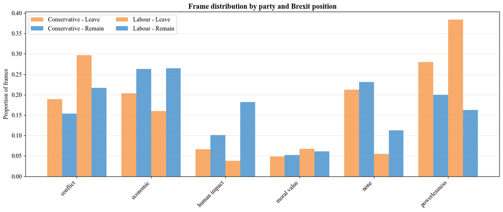

### Separate Visualization per Party

For each party, we show the frame distribution for Leave and Remain MPs side by side.

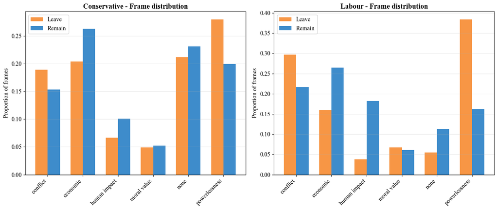

### Frame Distribution by Party for Remain MPs

This visualization shows the frame distribution for Remain MPs, comparing Conservative and Labour parties side by side for each frame.

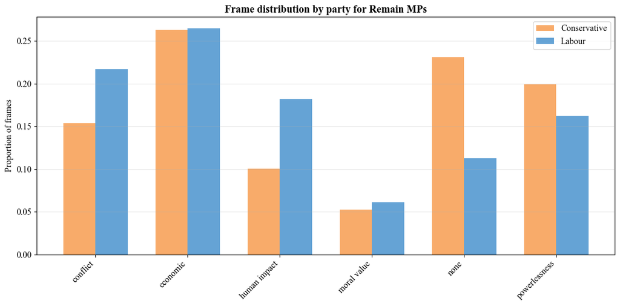

```
Frame counts by party for Remain MPs:
```

| party frame_label | Conservative | Labour |
| --- | --- | --- |
| conflict | 2077 | 2968 |
| economic | 3559 | 3622 |
| human impact | 1361 | 2492 |
| moral value | 707 | 832 |
| none | 3130 | 1542 |
| powerlessness | 2699 | 2219 |

```
Frame proportions by party for Remain MPs:
```

| party frame_label | Conservative | Labour |
| --- | --- | --- |
| conflict | 0.153 | 0.217 |
| economic | 0.263 | 0.265 |
| human impact | 0.101 | 0.182 |
| moral value | 0.052 | 0.061 |
| none | 0.231 | 0.113 |
| powerlessness | 0.199 | 0.162 |

### Heatmap: Frame Proportions by Party and Brexit Position

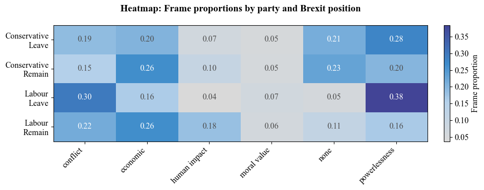

## Differences between Leave and Remain MPs within each Party

```
Differences in frame proportions (Leave - Remain):
```

|  | party | frame_label | leave_share | remain_share | difference | abs_difference |
| --- | --- | --- | --- | --- | --- | --- |
| 5 | Conservative | powerlessness | 0.279841 | 0.199438 | 0.080403 | 0.080403 |
| 1 | Conservative | economic | 0.203779 | 0.262987 | -0.059208 | 0.059208 |
| 0 | Conservative | conflict | 0.188777 | 0.153477 | 0.035300 | 0.035300 |
| 2 | Conservative | human impact | 0.066737 | 0.100569 | -0.033832 | 0.033832 |
| 4 | Conservative | none | 0.211969 | 0.231286 | -0.019318 | 0.019318 |
| 3 | Conservative | moral value | 0.048897 | 0.052243 | -0.003345 | 0.003345 |
| 11 | Labour | powerlessness | 0.384040 | 0.162267 | 0.221773 | 0.221773 |
| 8 | Labour | human impact | 0.037406 | 0.182230 | -0.144824 | 0.144824 |
| 7 | Labour | economic | 0.159601 | 0.264863 | -0.105262 | 0.105262 |
| 6 | Labour | conflict | 0.296758 | 0.217038 | 0.079720 | 0.079720 |
| 10 | Labour | none | 0.054863 | 0.112761 | -0.057898 | 0.057898 |
| 9 | Labour | moral value | 0.067332 | 0.060841 | 0.006491 | 0.006491 |

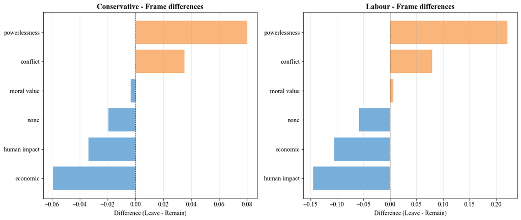

## Statistical Tests

We perform chi-square tests to check whether frame distributions differ significantly between Leave and Remain MPs within each party.

```
Chi-square test results:
```

|  | party | chi2_stat | p_value | dof | cramers_v | n_observations | significant |
| --- | --- | --- | --- | --- | --- | --- | --- |
| 0 | Conservative | 418.720230 | 2.734450e-88 | 5 | 0.127235 | 25865 | True |
| 1 | Labour | 199.328302 | 3.954587e-41 | 5 | 0.118999 | 14076 | True |

```
Interpretation:
Conservative: χ² = 418.72, p = 0.0000, Cramér's V = 0.127 (significant)
Labour: χ² = 199.33, p = 0.0000, Cramér's V = 0.119 (significant)
```